# Implementing INLA for a simple Gaussian model

Instructor: Sara Martino

**Aim of this practical:** In this exercise we are going to implement the INLA algorithm for a simple Gaussian model.

# 1 Introduction

Start by loading the necessary libraries

```r
library(ggplot2)
library(tidyverse)
library(patchwork)
```

We then define a smooth function:

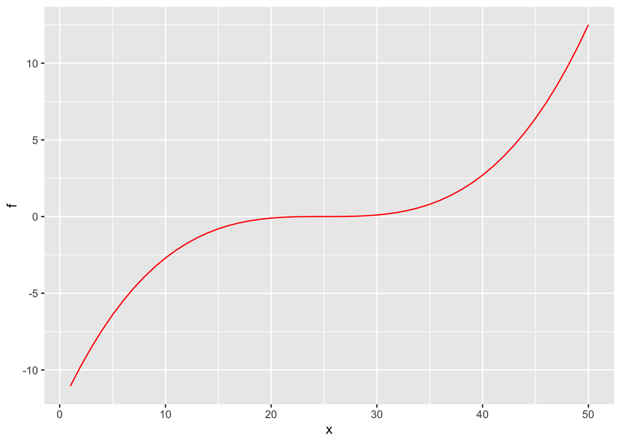

```r
n = 50
idx = 1:50
x = idx
func = 100 * ((idx-n/2)/n)^3
df = data.frame(x = x,  f = func)
ggplot(data = df) +   geom_line(aes(x,f), color = "red")
```

and simulate some data by adding noise. The noise is Gaussian distributed with variance 1
$$\epsilon_i\sim\mathcal{N}(0,1)$$

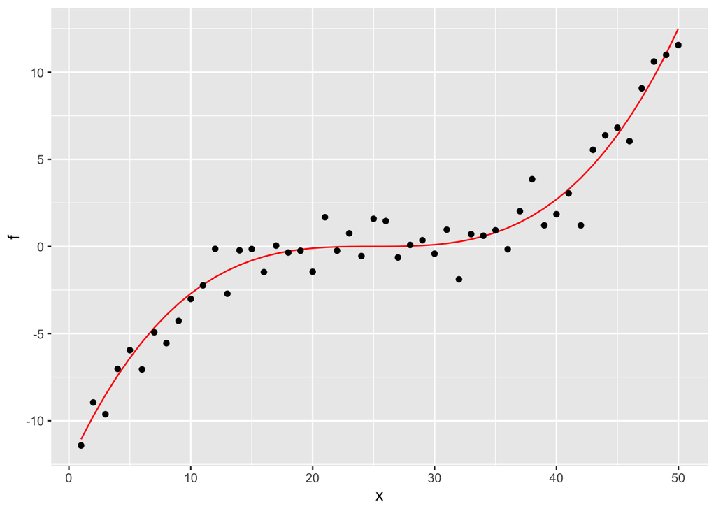

```r
y = func + rnorm(n, mean = 0, sd = 1)
df$y = y
ggplot(data = df) +
  geom_line(aes(x,f), color = "red") +
  geom_point(aes(x,y))
```

```r
obs = data.frame(x = x, y = y)
```

# 2 The model

Assume that, given $\mathbf{\eta} = (\eta_1,\dots,\eta_T)$, the observations $y_t$ are independent and Gaussian distributed with mean $\eta_t$ and known unit variance:
$$y_t|\eta_t = \mathcal{N}(\eta_t,1);\ t = 1,\dots,T$$

The linear predictor $\eta_t$ is linked to a smooth effect of time $t$ as:
$$\eta_t = f_t$$

Random walk models are a popular choice for modeling smooth effects of covariates or, as in this case, temporal effects . Here, we choose a first order random walk model (RW1) as prior distribution for the vector ${\mathbf f} = (f_1, \dots,f_T)$, so that:
$$\pi({\mathbf f}|\theta)\propto \theta^{(T-1)/2}\exp\left\{
-\frac{\theta}{2}\sum_{t=2}^T[f_t - f_{t-1} ]^2
\right\} = \mathcal{N}(\mathbf{0},\mathbf{Q}({\theta})^{-1}).$$
Thus, ${\mathbf f}|\theta$ is Gaussian distributed with mean $\mathbf{0}$ and precision (inverse covariance) matrix $\mathbf{Q}({\theta})$. The precision parameter $\theta$ controls the smoothness of the vector $\mathbf{f}$.

$$\pi(\theta)\propto \theta^{a-1}\exp(-b\theta)$$

**Question 1:** Write down the model as a LGM. What is the latent field $\bf{x}$ and what is the hyperparameter $\theta$ Solution

**Question 2:** Can you explicitly write down the elements of the precision matrix $\mathbf{Q}(\theta)$ Solution

# 3 The INLA scheme

- **Step I** Compute $\pi({\theta}|y)$ for a regular grid series of points ${\theta}_k$, $k = 1,\dots,K$.
- **Step II** For each ${\theta}_k$ and $i$ compute
  - $\pi(x_i|{\theta}_k, {y})$
  - $\pi(\theta_k|y)$
  - $\Delta_k$
- **Step III** For each $i$, sum out ${\theta}_k$
  $$\widetilde{\pi}(x_i|{y}) = \sum_k \widetilde{\pi}(x_i|{\theta}_k, {y})
  \times
  \widetilde{\pi}({\theta}_k|{y}) \times \Delta_k.$$

## 3.1 Step I

We want to compute
$$\pi({\theta}|y) \propto
\frac{\pi(y|x)\pi(x|\theta)\pi(\theta)}{\pi(x|y,\theta)}$$

for each value of $\theta$ in the grid

```r
theta = seq(0.01,2.5,length.out = 25)
Delta = diff(theta)[1]
```

Try to complete the following code in ordet to achieve this. You can look at the solution here if you have problems.

```r
# define the adjacency matrix
R = matrix(0,n,n)
diag(R) = c(1,rep(2,n-2),1)
for(i in 2:n)
  R[i-1,i] =R[i,i-1] = -1

# write a function that
# computes the log-likelihood
# y are the data
# x is the latent field
llik = function(y, x )
  ???

# write a function that computes the log prior
# for the latent field x
# x is the latent field
# theta the gridded values for the hyperpar
lpriorX = function(x,theta)
  ???

# function that computes the log prior
# for the hyperpar
# a,b are the parameters in the Gamma hyperprior
lpriorTheta = function(theta,a,b)
  ???

# function that computes the log
# full conditional \pi(x|t,\theta)
lfullcond = function(y,theta,x)
  ???



# compute the posterior for each
# \theta value in the grid
lposterior = numeric(length(theta))
for(i in 1:length(theta))
  lposterior[i] = llik(y,x) +
    lpriorX(x,theta[i]) +
    lpriorTheta(theta[i]) -
  lfullcond(y,theta[i],x)

# normalize the density
lposterior = lpost-max(lpost)
posterior = exp(lposterior)
norm_const = sum(posterior * Delta)
posterior = posterior/norm_const

plot(theta, posterior/norm_const)
```

## 3.2 Step II

Here we compute the posterior for the 10th element of vector $\bf{x}$, $x_{10}$.

We have now computed both $\pi(\theta_k|y)$ and $\Delta_k$ so what is left is to compute $\pi(x_{10}|\theta, y)$ for each value of $\theta_k$ in out grid.

There are several ways to solve this, here we follow the most straight forward method:

For each value $\theta_k$ - compute -

Consider the values for $x_{10}$

```r
xval = seq(-5,2,0.01)
```

Here we write a function that outputs $E(\eta_{10}|\theta_k,y)$ and $\text{Var}(\eta_{10}|\theta_k,y)$. If you have trouble you can find the answer here:

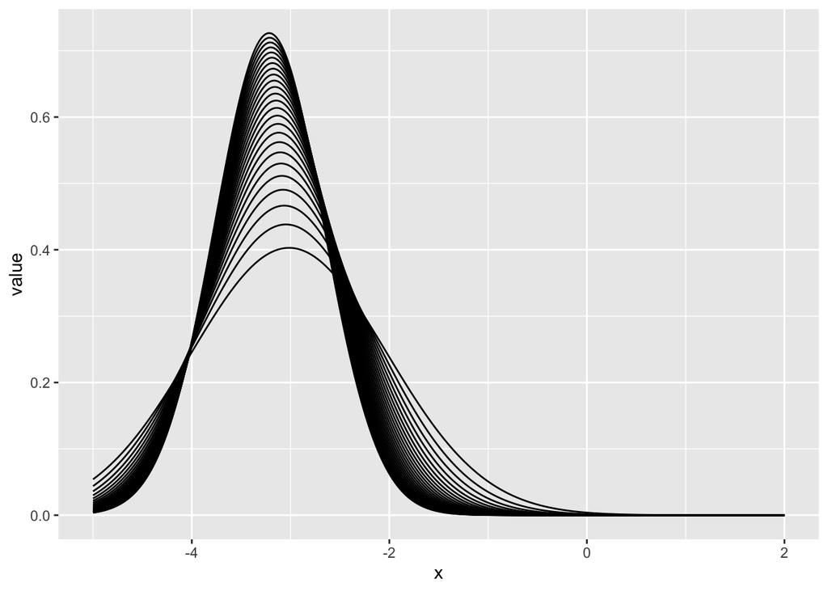

```r
# function that computes pi(\eta|theta,y) for a
# given value of theta
dens_eta_i_giventheta = function(xval, ii, theta_j, y) {

  Qprior = theta_j * R
  Qpost  = ??
  Sigma_post = solve(Qpost)
  mean_post = ??
  pi = dnorm(xval, mean = mean_post[ii],
             sd= sqrt(Sigma_post[ii,ii]))
  return(pi)
}

# Compute the densities for each value of theta and plot them
eta_val = matrix(NA, length(xval), length(theta))
for(j in 1:length(theta))
  eta_val[,j] = dens_eta_i_giventheta(xval, i = 10, theta[j], y)

data.frame(x = xval, eta_val) %>%
  pivot_longer(-x) %>%
  ggplot() + geom_line(aes(x,value, group = name))
```

## 3.3 Step III

The next step is to weight each of the computed densities as:
$$\pi(\eta_{10}|\theta_k,y)\pi(\theta_k)\Delta_k$$
and then compute the sum as

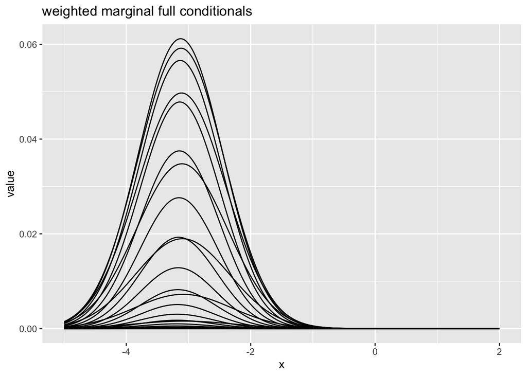

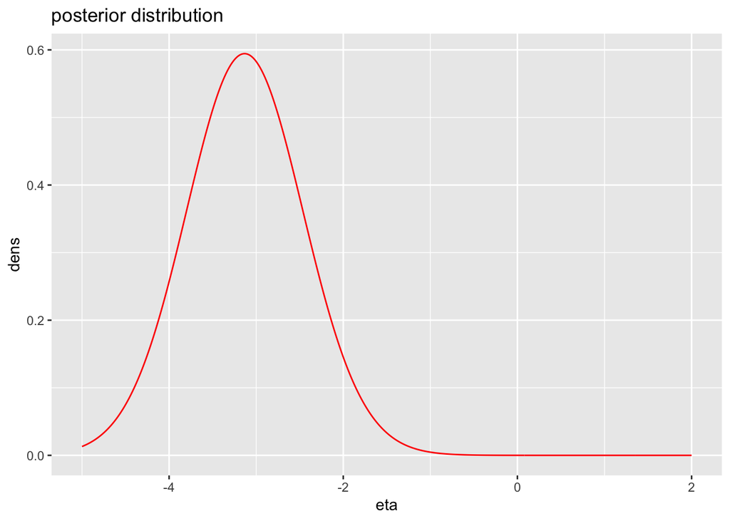

```r
for(j in 1:length(theta))
  eta_val[,j] = ???


# plot the weighted densities
p1 = data.frame(x = xval, eta_val) %>%
  pivot_longer(-x) %>%
  ggplot() + geom_line(aes(x,value, group = name)) +
  ggtitle("weighted marginal full conditionals")
p1

dens_eta = apply(eta_val,1,sum)
norm_cons = ???
dens_eta = dens_eta/norm_cons

sol = data.frame(eta = xval, dens = dens_eta)
p2 = ggplot() + geom_line(data = sol, aes(eta, dens), color = "red") + ggtitle("posterior distribution")
p2
```

Finally you can compare your answer with what the `inla()` function does:

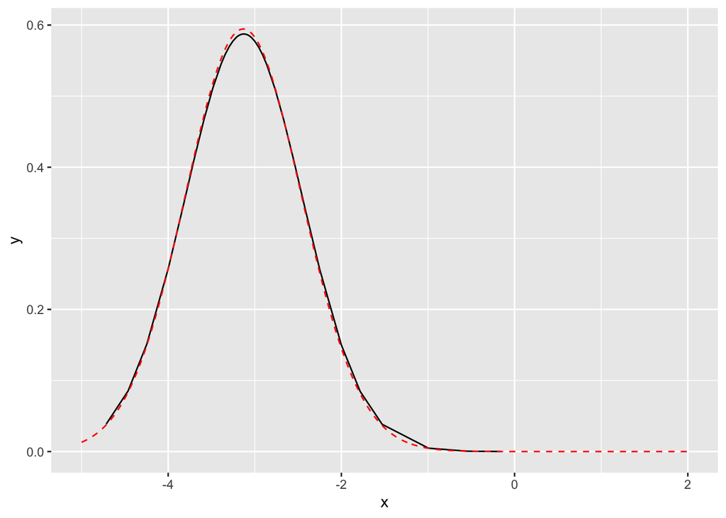

```r
library(INLA)
formula = y ~ -1 + f(idx, model="rw1", constr=FALSE,
   hyper=list(prec=list(prior="loggamma", param=c(10,10))))

result = inla(formula,
      data = data.frame(y=y, idx=idx),
      control.family = list(initial = log(1), fixed=TRUE))

ggplot() +
  geom_line(data= data.frame(result$marginals.random$idx[[10]]),
            aes(x,y)) +
  geom_line(data = sol, aes(eta, dens), color = "red", linetype = "dashed") + xlim(-5,2)
```

**Question:** In step II we have computed the density $\pi(\eta_{10}|\theta,y)$ in the most naive way, do you see any problem in our algorithm that could make it unefficient if the model (or specifically if the latent field) is large? Solution

# 4 Solutions

## 4.1 Question 1

The latent field is $x = \{\eta_1,\dots,\eta_n\}$ and the hyperparameter is the precision parameter $\theta$

## 4.2 Question 2

The precision matrix is $n\times n$ symmetrical matrix
$$Q(\theta) = \theta \ R$$
with
$$R = \left[\begin{array}
{rrrrrrrrrr}
1 & -1 & & & & & & & & \\
-1 & 2 & -1 & & & & & & \\
& -1 & 2 & -1 & & & & & \\
& & & & \ddots & & & & \\
& & & & & -1 & 2 & -1 &\\
& & & & & & -1 & 2 & -1 \\
& & & & & & & -1 & 1 \\
\end{array}
\right]$$

## 4.3 Question 3

```r
# define the adjacency matrix
R = matrix(0,n,n)
diag(R) = c(1,rep(2,n-2),1)
for(i in 2:n)
  R[i-1,i] =R[i,i-1] = -1

# function that computes the log-likelihood
llik = function(y,x)
  return(-sum(0.5*(y-x)^2))

# function that computes the log prior
# for the latent field x
lprior_latent = function(x,theta)
  return(-theta/2*t(x)%*%R%*%x)

# function that computes the log prior
# for the hyperpar
lprior_theta = function(theta,a = 10,b = 10)
{
    return((a-1)*log(theta)-b*theta)
}

# function that computes the log
# full conditional \pi(x|t,\theta)
lfullcond = function(y,theta,x)
{
  Q = theta * R + diag(n)
  b = t(y) %*% diag(n)
  return(-0.5*t(x)%*%Q%*%x+b%*%x)
}


# compute the posterior for each
# \theta value in the grid
lposterior = numeric(length(theta))
for(i in 1:length(theta))
  lposterior[i] = sum(llik(y,x)) +
    lpriorX(x,theta[i]) +
    lpriorTheta(theta[i]) -
  lfullcond(y,theta[i],x)



# normalize the density
lposterior = lpost-max(lpost)
posterior = exp(lposterior)
norm_const = sum(posterior * Delta)
posterior = posterior/norm_const

p1 = data.frame(theta=theta, f=posterior) %>%
  ggplot(aes(theta,f)) + geom_point() +
  scale_x_continuous(name = expression(theta)) +
  scale_y_continuous(name = "density")  +
  ggtitle(bquote('Posterior marginals for'~theta ))

p1
```

## 4.4 Question 4

```r
# function that computes pi(\eta|theta,y) for a
# given value of theta
#
dens_eta_i_giventheta = function(xval, ii, theta_j, y) {

  Qprior = theta_j * R
  Qpost  = Qprior + diag(n)
  Sigma_post = solve(Qpost)
  mean_post = (Sigma_post %*% y)
  pi = dnorm(xval, mean = mean_post[ii],
             sd= sqrt(Sigma_post[ii,ii]))
  return(pi)
}
```

## 4.5 Question 5

```r
for(j in 1:length(theta))
  eta_val[,j] = eta_val[,j] * dens[j] * Delta


# plot the weighted densities
p1 = data.frame(x = xval, eta_val) %>%
  pivot_longer(-x) %>%
  ggplot() + geom_line(aes(x,value, group = name)) +
  ggtitle("weighted marginal full conditionals")
p1

dens_eta = apply(eta_val,1,sum)
norm_cons = sum(dens_eta * diff(xval)[1])
dens_eta = dens_eta/norm_cons

sol = data.frame(eta = xval, dens = dens_eta)
p2 = ggplot() + geom_line(data = sol, aes(eta, dens), color = "red") + ggtitle("posterior distribution")
p2
```

## 4.6 Question 6

Inverting the precision matrix $Q(\theta)$ in order to find the posterior means and variance can be computationally very intensity when $x$ is a large vector.

The way INLA does this is to exploit the fact that $Q(\theta)$ is sparse and means and variances can be computed using a smart algorithm (Rue and Martino 2007) that avoids having to invert the precision matrix.

# References

Rue, Håvard, and Sara Martino. 2007. “Approximate Bayesian Inference for Hierarchical Gaussian Markov Random Field Models.” *Journal of Statistical Planning and Inference* 137 (10): 3177–92. https://doi.org/https://doi.org/10.1016/j.jspi.2006.07.016.